# RESQUE Profile for Max Mustermann Demoprofile

# Contributorship profile (CRediT roles)

Based on 3 submitted publications, this is the self-reported contributorship profile:

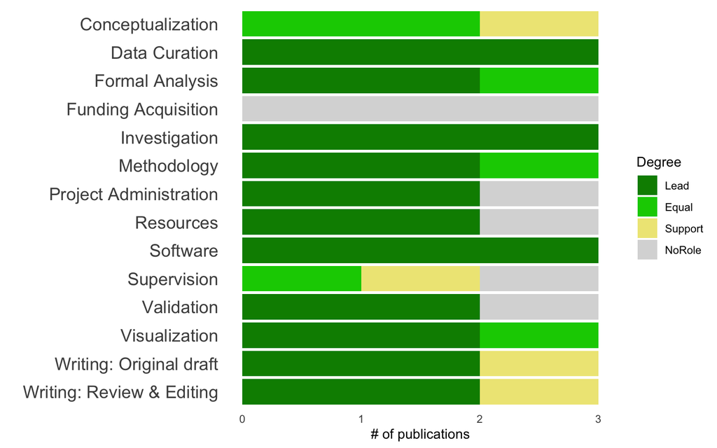

# Indicators of Research Transparency and Reproducibility

## Overview of open research practices

| Open Data Available | Preregistration available | Open Material available | Open Code available | Correctness of computational results has been independently verified |
| --- | --- | --- | --- | --- |

## Rigor profile overview

**Methods: Computation of the relative rigor score**

**How to read the relative rigor score**

The general philosophy of RESQUE is: It doesn’t matter so much what kind of research you do - but when you do it, you should do it in a high quality. The radar chart with the **Relative Rigor Score** helps you to see how many quality indicators have been fulfilled in multiple areas of methodological rigor.

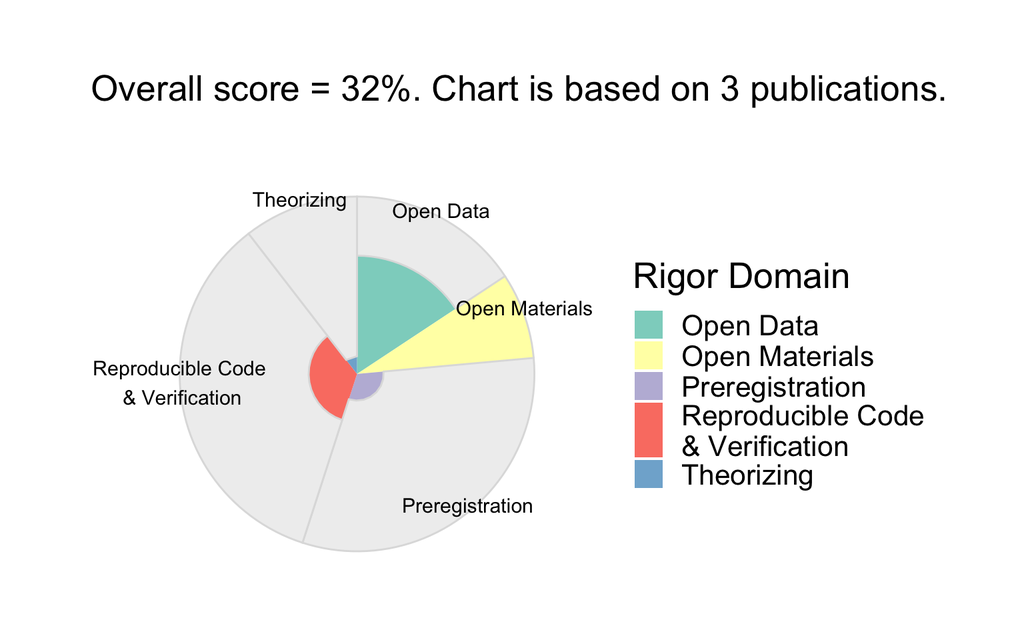

# Scientific impact

[BIP! Scholar](https://bip.imsi.athenarc.gr/site/home) (a non-commercial open-source service to facilitate fair researcher assessment) provides **five impact classes** based on norm values:

| 🚀 Top 0.01% | ️🌟 Top 0.1% | ️✨ Top 1% | Top 10% | Average (Bottom 90%) |
| --- | --- | --- | --- | --- |

**Methods: Computation of the Popularity metric**

This indicator reflects impact/attention of an article in the research community at large. It is based on *AttRank*, a variation of PageRank (known from the Google search algorithm) that accounts for the temporal evolution of the citation network. By that, it alleviates the bias against younger publications, which have not had the chance to accumulate a lot of citations. It models a researcher’s preference to read papers which received a lot of attention recently. It was evaluated (and vetted) in its performance to predict the ranking of papers concerning their *future impact* (i.e., citations). For more details, see [BIP! glossary](https://bip.imsi.athenarc.gr/site/indicators) and the references therein.

**Methods: CRediT Levels of involvement**

We categorized papers into levels of involvement, based on the degrees of contributorship:

| Involvement.Level | Definition | Publications |
| --- | --- | --- |
| Very High | (>=3 roles as *lead*) OR (>= 5 roles as (*lead* OR *equal*)) | 3 |
| High | (1-2 roles as *lead*) OR (3-4 roles as *equal*) | 0 |
| Medium | (1-2 roles as *equal*) OR (>= 5 roles as *support*) | 0 |
| Low | All other combinations | 0 |

## Highly popular publications

[output not shown]

Note:  
FNCS = Field- and age-normalized citation score: This is the factor by which a publication is cited more often than other publications from the same field and the same publication year. A value of 2, for example, indicates that the publication got cited twice as much as comparable publications.

## Publications without citation metrics & average popular publications

For very new publications, no citation metrics can be computed.

[output not shown]

Note:  
FNCS = Field- and age-normalized citation score: This is the factor by which a publication is cited more often than other publications from the same field and the same publication year. A value of 2, for example, indicates that the publication got cited twice as much as comparable publications.

# Internationality and Interdisciplinarity

**Methods: Computation of Internationality and Interdisciplinarity**

The analysis is only based on the submitted publications (not the entire publication list) of the applicant. Publication and co-author data is retrieved from the OpenAlex data base. Note that preprints are not indexed by OpenAlex and therefore do not contribute to this analysis.

- *Internationality*: All co-authors are retrieved from OpenAlex with their current affiliation. The index is measured by Pielou’s Evenness Index (Pielou 1966) of the country codes of all co-authors. It considers the 10 most frequent country codes.
- *Interdisciplinarity* is measured by the Evenness Index of the fields (as classified by OpenAlex) of the publications. It considers the 6 most frequent fields.

The evenness indexes are normalized to a scale from 0 (no diversity, everything is one category) to 1 (maximum diversity, all categories are equally represented). It is computed as a normalized Shannon entropy.

**Internationality**

**Interdisciplinarity**

Only within country co-authors

Broad coauthor network from many countries

Single discipline

Many disciplines

7 unique identifiable co-authors:

- 0% from 0 international countries
- 100% from the same country

1 primary fields:

- Neuroscience (3)

| Co-authors' Country Code | # of Co-authors |
| --- | --- |
| DE | 7 |

The main subfields are (multiple categories per paper are possible):

[output not shown]